# 10 Multidimensionality: Continued II

Psychologisches Institut, Lehrstuhl für psychologische Methodenlehre, Evaluation und Statistik

~

Carolina Fellinghauer

carolina.fellinghauer@uzh.ch

18.11.2020

# Getting ready

```r
library(mirt)
```

# Multidimensionality

Also, a test form should measure only one construct. Multidimensionality indicates that the ability of test respondent is not on one continuum across the test questions. If several separate dimensions are included, the validity of one summary total score is not supported. In presence of multidimensionality, the different dimensions measure aspects of the latent trait that do not align. In that sense, if multidimensionality holds, the ability that is measured are supposed to differ significantly across the dimensions.

# Diagnostics

As shown previously, unidimensionality can be examined with a Principal Component Analysis (PCA) of the standardized Rasch residuals (Smith 2002). If unidimensionality holds, no factor structure should be found in the residuals.

The absence of two distinct dimensions can be tested statistically with t-tests comparing pairs of ability estimates from separate Rasch calibration of the 2 sets of items, either loading positively ($PC^+$) or negatively ($PC^-$) on the first component of the PCA. The test is carried out for each $\hat{\theta}$ pair using the standard t-test formula:

$$t_{(1,\infty)} =\frac{ \hat{\theta}_{PC^+} - \hat{\theta}_{PC^-} }
{\sqrt{\hat{\sigma}^2_{PC^+} + \hat{\sigma}^2_{PC^-} } }$$

The percentage of significant t-tests should not exceed 5% (Andrich and Marais 2019).

Comparing the ability estimates from two separate unidimensional analysis of the items loading either negatively or positively on the first component is statistically not sound, as the ability estimates cannot be expected to address the same continuum.

Comparing the ability estimates from the two dimensions on the first component requires applying a technique called *anchoring*.

In very detail, the correct way to go is to:

1. Run a unidimensional Rasch analysis with all the items.
2. Determine the dimensions, i.e. those which load negatively or positively on the first component of the PCA.
3. Set aside the common item parameter estimates.
4. Anchor the items from each dimension on the parameter estimates from 3).
5. Run separate anchored analyses and extract the person parameter (*ability*).
6. Make a t-test (based on formula) for each persons (per row) pair of ability estimates.
7. Find the proportion of pairs of ability estimates with significant t-test ($|t-value| > 2.5$).
8. If the proportion is > 5%, unidimensionality must be rejected.

Unfortunately, `eRm` does not allow to anchor item difficulty estimates. Fortunately, `mirt` does.

## Numeric Output analysis

Let’s go through this test step by step using, as previously, the MDS dataset.

```r
urlfile <- "https://raw.githubusercontent.com/CarolinaFellinghauer/UNIZH_HS2020_Rasch/master/Data/WHO_MDS_course.csv"

MDS.data <- read.csv(url(urlfile), sep = ";")

dim(MDS.data)
```

```
[1] 1000   26
```

```r
colnames(MDS.data)
```

```
 [1] "ID"            "sex"           "age"           "HealthStatus"
 [5] "Vision"        "Hearing"       "Walking"       "Memory"
 [9] "Dressing"      "Communication" "Feeding"       "Toileting"
[13] "Bed"           "GoingOut"      "Shopping"      "HandUse"
[17] "Sleeping"      "Breathing"     "Household"     "Caring"
[21] "Participating" "Depressivity"  "Anxiety"       "GettingAlong"
[25] "Managing"      "Pain"
```

```r
# Select only the MDS items, these are all columns except the first four.  It
# starts with vision.

mds.items <- colnames(MDS.data)[-(1:4)]

data.mds <- MDS.data[, mds.items]
data.mds <- data.mds - 1
```

**1)** Run a unidimensional Rasch analysis with all the items.

```r
mds.1dim <- mirt(data.mds, 1, itemtype = "Rasch", verbose = FALSE)
```

**2)** Determine the dimensions, i.e. those which loaded negatively or positively on the first component of the PCA.

As shown previously, the Q3, standardized residual correlations enter the PCA.

```r
cor.mds <- residuals(mds.1dim, type = "Q3", verbose = FALSE)  #gives the correlation of the standardized residuals

PCA.mds <- eigen(cor.mds)
PC1.neg <- which(PCA.mds$vectors[, 1] < 0)  # negative sign on PC1
PC1.pos <- which(PCA.mds$vectors[, 1] > 0)  # positive sign on PC1
```

**3)** Set aside the common item parameter estimates.

The function `coef()` gives the item parameter estimates, option `simplify = TRUE` puts it in a nice matrix format.

```r
coef.mds.1dim <- coef(mds.1dim, simplify = TRUE)
coef.mds.1dim
```

```
$items
              a1 ak0 ak1 ak2 ak3 ak4 d0     d1     d2     d3     d4
Vision         1   0   1   2   3   4  0  0.776  2.075  2.320  1.679
Hearing        1   0   1   2   3   4  0 -1.098 -1.229 -2.162 -3.365
Walking        1   0   1   2   3   4  0  0.232  1.343  1.673  1.698
Memory         1   0   1   2   3   4  0  0.236  0.741  0.058 -0.482
Dressing       1   0   1   2   3   4  0 -0.735 -0.542 -0.706 -1.041
Communication  1   0   1   2   3   4  0 -1.440 -1.718 -2.561 -3.224
Feeding        1   0   1   2   3   4  0 -1.413 -1.523 -2.280 -2.616
Toileting      1   0   1   2   3   4  0 -1.642 -1.095 -1.652 -1.483
Bed            1   0   1   2   3   4  0 -0.723 -0.266 -0.387 -0.390
GoingOut       1   0   1   2   3   4  0 -0.421  0.188  0.437  1.031
Shopping       1   0   1   2   3   4  0 -0.516  0.095  0.540  1.295
HandUse        1   0   1   2   3   4  0 -0.817 -0.262 -0.427 -0.802
Sleeping       1   0   1   2   3   4  0 -0.004  1.214  1.318  0.698
Breathing      1   0   1   2   3   4  0 -0.408 -0.410 -1.481 -2.811
Household      1   0   1   2   3   4  0 -0.287  0.596  0.488  0.880
Caring         1   0   1   2   3   4  0 -0.821 -0.201 -0.308  0.258
Participating  1   0   1   2   3   4  0 -0.299  0.079  0.434  1.239
Depressivity   1   0   1   2   3   4  0  0.806  1.816  1.866  1.486
Anxiety        1   0   1   2   3   4  0  1.239  2.196  2.290  1.837
GettingAlong   1   0   1   2   3   4  0 -1.295 -1.688 -2.526 -3.270
Managing       1   0   1   2   3   4  0 -0.407  0.304 -0.086  0.275
Pain           1   0   1   2   3   4  0  1.323  3.164  3.525  3.533

$means
F1
 0

$cov
     F1
F1 1.59
```

**4)** Anchor the items from each dimension on the parameter estimates in 3).

The anchoring is not intuitive, requires careful consideration of different options that the `mirt()` function contains. Each threshold has to be fixed to the estimated thresholds parameter from the common calibration.

First, the items that loaded negatively on the first component:

```r
# Analysis of the first dimension

# First run a Rasch analysis, as usual, but with option pars = 'values'

mod.mds.dim1 <- mirt(data.mds[, PC1.neg], 1, itemtype = "Rasch", pars = "values")

# get the coefficient matrix and replace the values with those from the common
# calibration to fix the first ,second, third, and fourth threshold.

mod.mds.dim1[which(mod.mds.dim1[, "name"] == "d1"), "value"] <- coef.mds.1dim$items[PC1.neg,
    "d1"]
mod.mds.dim1[which(mod.mds.dim1[, "name"] == "d2"), "value"] <- coef.mds.1dim$items[PC1.neg,
    "d2"]
mod.mds.dim1[which(mod.mds.dim1[, "name"] == "d3"), "value"] <- coef.mds.1dim$items[PC1.neg,
    "d3"]
mod.mds.dim1[which(mod.mds.dim1[, "name"] == "d4"), "value"] <- coef.mds.1dim$items[PC1.neg,
    "d4"]

# finally set this, otherwise the anchored analysis will not be kept fixed.
mod.mds.dim1$est <- FALSE
```

Next, same procedure, with the items that loaded positively on the first component:

```r
# First run a Rasch analysis with option pars = 'values'

mod.mds.dim2 <- mirt(data.mds[, PC1.pos], 1, itemtype = "Rasch", pars = "values")

# get the coefficient matrix and replace the values with those from the common
# calibration to fix the first ,second, third, and fourth threshold.
mod.mds.dim2[which(mod.mds.dim2[, "name"] == "d1"), "value"] <- coef.mds.1dim$items[PC1.pos,
    "d1"]
mod.mds.dim2[which(mod.mds.dim2[, "name"] == "d2"), "value"] <- coef.mds.1dim$items[PC1.pos,
    "d2"]
mod.mds.dim2[which(mod.mds.dim2[, "name"] == "d3"), "value"] <- coef.mds.1dim$items[PC1.pos,
    "d3"]
mod.mds.dim2[which(mod.mds.dim2[, "name"] == "d4"), "value"] <- coef.mds.1dim$items[PC1.pos,
    "d4"]

# next set this, otherwise the anchored analysis will not keep the estimates
# fixed.
mod.mds.dim2$est <- FALSE
```

**5)** Run separate anchored analyses.

The option `pars =` shows that the item parameter are fixed to the values of the common calibration now.

```r
mod.PCM.dim1 <- mirt(data.mds[, PC1.neg], 1, itemtype = "Rasch", pars = mod.mds.dim1)  #anchored analysis

mod.PCM.dim2 <- mirt(data.mds[, PC1.pos], 1, itemtype = "Rasch", pars = mod.mds.dim2)  #anchored analysis
```

**6)** Make a t-test (based on formula) for each pair of ability estimates.

The function `fscores()` allows to extract the theta estimates, setting `full.scores.SE = TRUE` further provides the precision of the estimates, which is also required for the t-test.

```r
Theta.dim1 <- fscores(mod.PCM.dim1, full.scores.SE = TRUE)
Theta.dim2 <- fscores(mod.PCM.dim2, full.scores.SE = TRUE)
```

The ability estimates from the two dimensions can be plotted against each other. Ideally, if the ability estimates do not differ, the points should fall on or closely around the diagonal

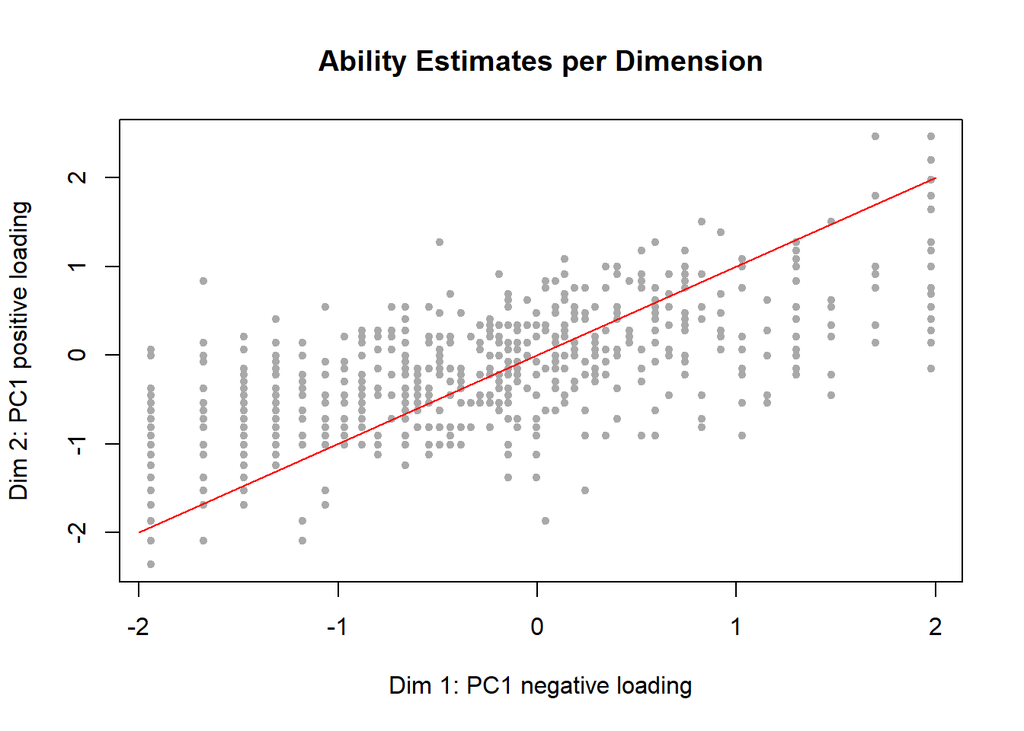

```r
plot(Theta.dim1[, 1], Theta.dim2[, 1], xlab = "Dim 1: PC1 negative loading", ylab = "Dim 2: PC1 positive loading",
    main = "Ability Estimates per Dimension", pch = 20, col = "darkgrey")

segments(x0 = -2, y0 = -2, x1 = 2, y1 = 2, col = "red")
```

The t-test has to be computed manually, for each pair of ability estimate, i.e. per person.

$$t_{(1,\infty)} =\frac{ \hat{\theta}_{PC^+} - \hat{\theta}_{PC^-} }
{\sqrt{\hat{\sigma}^2_{PC^+} + \hat{\sigma}^2_{PC^-} } }$$

```r
T_test_abs <- abs(Theta.dim1[, "F1"] - Theta.dim2[, "F1"])/sqrt(Theta.dim1[, "SE_F1"]^2 +
    Theta.dim2[, "SE_F1"]^2)
```

**7)** Find the proportion of pairs of ability estimates with significant t-test.

```r
sum(T_test_abs > 2.5)/length(T_test_abs) * 100
```

```
[1] 10.5
```

**8)** If the proportion is > 5%, unidimensionality must be rejected. Here, there are 10.5% of significant t-tests, that is too much to support the unidimensionality of the MDS-items.

# Exercise

Reproduce and reflect about the steps for the t-test for multidimensionality with the SRG-Data. Show that the coefficients from the common calibration are identical with those from the anchored analysis.

Andrich, D., and I. Marais. 2019. *A Course in Rasch Measurement Theory : Measuring in the Educational, Social and Health Sciences*.

Smith, E. V. 2002. “Detecting and Evaluating the Impact of Multidimensionality Using Item Fit Statistics and Principal Component Analysis of Residuals.” *J Appl Meas* 3 (2): 205–31.